# Cross-Asset Information in Bitcoin Intraday Price Prediction，Using Gold and the S&P 500

# 1. Introduction：When finding the relationship between Bitcoin and traditional macro-financial assets, we notice an interesting thing

In the early time of Bitcoin’s development, it acted more like a substitute to traditional commodities—when one price went up, the other often went down, showing a kind of inverse movement.

But in recent years, as Bitcoin’s market size grew and more people get into it, this relationship started to shift to another side.

Now, more and more, Bitcoin’s price trend begins to move in the same direction (in phase) with the real economy or traditional assets. In other words, its price began to align positively with macro market trends like U.S. stocks, gold, or even policy changes.

This makes us wonder: is Bitcoin becoming a kind of complement rather than a substitute?

**If so, can we try to use the early moves of traditional markets to predict Bitcoin’s future direction?**

That’s the core question I want to explore in this project.

When choosing the model, I started with LSTM as the base layer. One reason is that it was relatively mature for time series tasks (at least in 2 years ago when I finished most of the work of this project). Another reason is honestly because I hadn’t really touched Transformer models yet at taht time, haha.

If I get more time later, I might try to extend the model—maybe use Diffusion-based architectures and see if they can improve prediction performance.

```python
# import
import pandas as pd
import numpy as np
import matplotlib.pyplot as plt
from sklearn.preprocessing import MinMaxScaler
import tensorflow as tf
from tensorflow.keras.models import Sequential
from tensorflow.keras.layers import LSTM, Dense, Dropout
from tensorflow.keras.callbacks import EarlyStopping, ModelCheckpoint
from scipy.stats import pearsonr, binomtest

print("TensorFlow ver:", tf.__version__)
print("GPU number:", len(tf.config.list_physical_devices("GPU")))
```

```
TensorFlow ver: 2.6.0
GPU number: 1
```

# 2. Data & Preprocessing

To build this model, I mainly used three types of market data, all at daily frequency (1 day).

Why daily? Because BTC trades 24/7, but obviously stocks don’t—so to avoid too much data loss, I picked 1-day as the most stable and consistent option.

The time span is roughly from Jan 1, 2014 to Dec 31, 2024—almost 4000 days—basically covering the full phase from Bitcoin’s speculative period to its recent gradual financialization.

Data sources:

Bitcoin (BTC/USDT): from Investing.com, includes daily price and volume

Gold (GLD): from Investing.com, used as a traditional safe-haven asset

S&P 500 Index (SP500): also from Investing, used as a representation for the overall U.S. stock market

For the next steps, all features will be extracted, combined, and normalized based on this cleaned dataset.

```python
# 1) Read three CSV files
btc   = pd.read_csv("BTC1.csv",   parse_dates=["Date"], index_col="Date")[["Price","Change %","Vol."]]
gld   = pd.read_csv("GOLD1.csv",   parse_dates=["Date"], index_col="Date")[["Change %","Vol."]]
sp500 = pd.read_csv("SP5001.csv", parse_dates=["Date"], index_col="Date")[["Change %","Vol."]]

# 2) Rename close price and volume columns
gld.rename(columns={"Change %":"GLD_Change %",   "Vol.":"GLD_Vol"},   inplace=True)
sp500.rename(columns={"Change %":"SP500_Change %","Vol.":"SP500_Vol"}, inplace=True)

# 3) Merge +  forward-fill + drop na
df = pd.concat([
    btc[["Change %","Vol."]],
    gld[["GLD_Change %","GLD_Vol"]],
    sp500[["SP500_Change %"]]
], axis=1)

df.ffill(inplace=True)
df.dropna(inplace=True)
print(df.head())
print(df.columns)
df.shape
```

```
           Change %   Vol. GLD_Change % GLD_Vol SP500_Change %
Date
2014-01-02    4.69%  0.13K        1.62%   7.57M         -0.89%
2014-01-03    4.78%  0.13K        1.09%   5.88M         -0.03%
2014-01-04   -1.26%  0.01K        1.09%   5.88M         -0.03%
2014-01-05   12.74%  0.02K        1.09%   5.88M         -0.03%
2014-01-06    3.38%  0.10K        0.18%  10.11M         -0.25%
Index(['Change %', 'Vol.', 'GLD_Change %', 'GLD_Vol', 'SP500_Change %'], dtype='object')
```

```
(4015, 5)
```

Here, I chose the percentage changes (volatility) of BTC, gold, and SP500 as inputs, instead of their actual real price values. The detailed reason for this choice is discussed later in the last **thoughts** section.

```python
# 4) Strip potential leading/trailing spaces
df.columns = df.columns.str.strip()

pct_cols = ['Change %', 'GLD_Change %', 'SP500_Change %']

df[pct_cols] = (
    df[pct_cols]
      .replace({'%': ''}, regex=True)   # Remove '%'
      .astype(float)                  # convert to float
      .div(100)                       # divide by 100
)                       # Remove '%' → convert to float → divide by 100

# 5）Replace K/M/B with scientific notation
vol_cols = [ 'Vol.', 'GLD_Vol']

df[vol_cols] = (
    df[vol_cols]
      .replace({',':''}, regex=True)      # Remove commas
      .replace({'K':'e3','M':'e6', 'B':'e9'}, regex=True)  # K→e3, M→e6
      .astype(float)                      # convert to float
)

# 6) Split by first appearance into train/test sets (80/20)
train_size = int(len(df) * 0.8)
df_train = df.iloc[:train_size]
df_test  = df.iloc[train_size:]

#Please note,for step 7,8,9 it is kind of useless here, most of the values do not change.I wrote when the price was in df.

# 7) Initialize MinMaxScaler
scaler = MinMaxScaler(feature_range=(0, 1))

# 8) Fit only on train set to avoid data leakage
scaler.fit(df_train)

# 9) Transform train and test sets
train_scaled = scaler.transform(df_train)
test_scaled  = scaler.transform(df_test)

df_train
```

| Date | Change % | Vol. | GLD_Change % | GLD_Vol | SP500_Change % |
| --- | --- | --- | --- | --- | --- |
| 2014-01-02 | 0.0469 | 130.0 | 0.0162 | 7570000.0 | -0.0089 |
| 2014-01-03 | 0.0478 | 130.0 | 0.0109 | 5880000.0 | -0.0003 |
| 2014-01-04 | -0.0126 | 10.0 | 0.0109 | 5880000.0 | -0.0003 |
| 2014-01-05 | 0.1274 | 20.0 | 0.0109 | 5880000.0 | -0.0003 |
| 2014-01-06 | 0.0338 | 100.0 | 0.0018 | 10110000.0 | -0.0025 |
| ... | ... | ... | ... | ... | ... |
| 2022-10-16 | 0.0103 | 780.0 | -0.0125 | 5470000.0 | -0.0237 |
| 2022-10-17 | 0.0148 | 1450.0 | 0.0029 | 4350000.0 | 0.0265 |
| 2022-10-18 | -0.0113 | 2120.0 | 0.0022 | 4530000.0 | 0.0114 |
| 2022-10-19 | -0.0104 | 860.0 | -0.0134 | 8260000.0 | -0.0067 |
| 2022-10-20 | -0.0039 | 1270.0 | -0.0016 | 5020000.0 | -0.0080 |

3212 rows × 5 columns

# 3 Model Bulid

```
Train shape: (3152, 60, 5) (3152,)
Test  shape: (743, 60, 5) (743,)
DirAcc: 67.97%
Pearson Correlation: 0.588
```

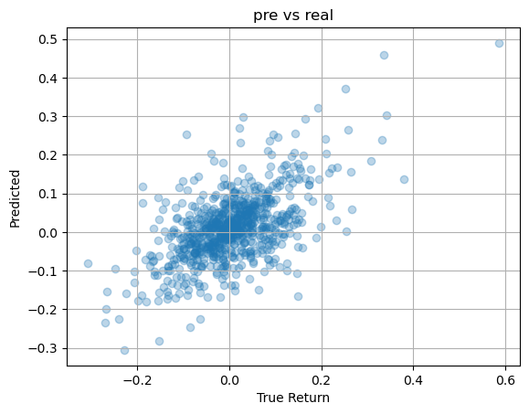

```python
# 10) Sliding window
window = 60                # Use past 60 days to predict the next day
price_idx = 0              # the 0th column of price
eps=1e-11
def make_xy_regression(data, window, price_idx):
    X, y = [], []
    for i in range(window, len(data)):
        X.append(data[i-window:i])
        ret = (data[i, price_idx] - data[i-1, price_idx]) / (data[i-1, price_idx]+eps)
        ret = np.clip(ret, -1, 1)
        y.append(ret)
    return np.array(X), np.array(y) # Use simple return as prediction target, clip to [-1, 1] to avoid outliers

X_train, y_train = make_xy_regression(train_scaled, window, price_idx)
X_test,  y_test  = make_xy_regression(test_scaled,  window, price_idx)

print("Train shape:", X_train.shape, y_train.shape)
print("Test  shape:", X_test.shape,  y_test.shape)

# 11) Build model
model = Sequential([
    LSTM(128, return_sequences=True, input_shape=(window, train_scaled.shape[1])),
    Dropout(0.05),
    LSTM(128, return_sequences=False),
    Dropout(0.01),
    Dense(1, activation='tanh')    # tanh ∈ [-1, 1]                          # Predict a single scalar
])

model.compile(optimizer='adam',
              loss='mse')   # or loss='mae'

# 11) Training
es = EarlyStopping(monitor='val_loss', patience=50, restore_best_weights=True)
ckpt = ModelCheckpoint('best_lstm.h5', save_best_only=True)

history = model.fit(
    X_train, y_train,
    epochs=300,
    batch_size=64,
    validation_split=0.15,
    shuffle=False,
    verbose=1
)

y_pred = model.predict(X_test).squeeze()

# 12) DirAcc (directional accuracy: proportion of correct up/down predictions)
sign_true = np.sign(y_test)
sign_pred = np.sign(y_pred)
diracc = np.mean(sign_true == sign_pred)
print(f"DirAcc: {diracc*100:.2f}%")

# 13) Correlation (how well predicted returns align with actual returns)
corr, _ = pearsonr(y_pred, y_test)
print(f"Pearson Correlation: {corr:.3f}")

# 14) Plot
plt.scatter(y_test, y_pred, alpha=0.3)
plt.xlabel("True Return"); plt.ylabel("Predicted")
plt.title("pre vs real")
plt.grid(True); plt.show()
```

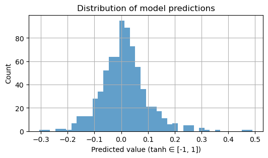

```python
# 15) Distribution
plt.figure(figsize=(6,3))
plt.hist(y_pred, bins=40, alpha=0.7)
plt.xlabel("Predicted value (tanh ∈ [-1, 1])")
plt.ylabel("Count")
plt.title("Distribution of model predictions")
plt.grid(True)
plt.show()
```

# 4. Back test and model performace

Simple back test on test data.

```
=== Strategy vs Buy & Hold ===
CAGR   : 44.45%  |  134.94%
Sharpe :  1.26  |   2.02
```

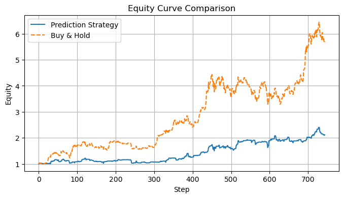

```
DirAcc            : 67.97%
  ↳ baseline (long): 50.74%  →  Δ = +17.23%
Pearson corr       :  0.588  (p = 2.68e-70)
Binom test vs 50%  : p = 2.9e-23
```

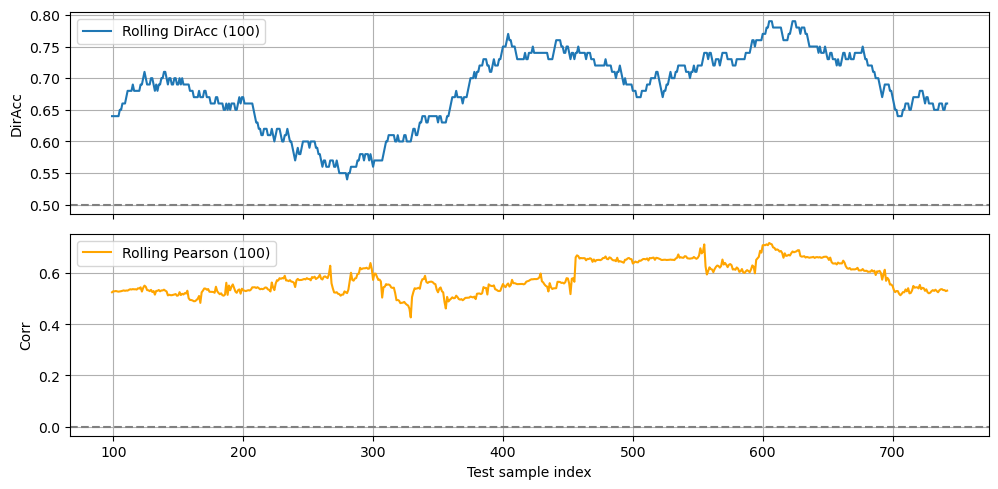

```python
# 16) Get raw daily return in test set

ret_col = 'Change %'
ret_arr = df_test[ret_col].astype(float).values

# 17) Generate position signals

threshold = 0.01                             # if |y_pred| ≤ threshold → do nothing
position  = (y_pred > threshold).astype(float)

# 18) Backtest

equity_pred, equity_bh = [1.0], [1.0]

for t in range(len(y_pred)):
    r = ret_arr[t + window]
    equity_pred.append(equity_pred[-1] * (1 + position[t] * r))
    equity_bh.append(  equity_bh[-1]   * (1 + r))

equity_pred, equity_bh = np.array(equity_pred), np.array(equity_bh)

# 19) Performance metrics

def cagr(eq, ppy=365):   # Compound annual growth rate
    return (eq[-1] / eq[0]) ** (ppy / len(eq)) - 1

def sharpe(eq, ppy=365): # Sharpe ratio
    r = np.diff(eq) / eq[:-1]
    return r.mean() / r.std() * np.sqrt(ppy)

print("\n=== Strategy vs Buy & Hold ===")
print(f"CAGR   : {cagr(equity_pred):6.2%}  |  {cagr(equity_bh):6.2%}")
print(f"Sharpe : {sharpe(equity_pred):5.2f}  |  {sharpe(equity_bh):5.2f}")

# 20) Equity curve visualization

plt.figure(figsize=(8, 4))
plt.plot(equity_pred, label='Prediction Strategy')
plt.plot(equity_bh,   label='Buy & Hold', linestyle='--')
plt.title("Equity Curve Comparison")
plt.xlabel("Step"); plt.ylabel("Equity"); plt.grid(True)
plt.legend(); plt.show()

# Prediction diagnostics

# 21) Directional accuracy and Pearson correlation
hit      = (np.sign(y_pred) == np.sign(y_test))
dir_acc  = hit.mean()                             # directional accuracy
baseline = (y_test > 0).mean()                    # always-long benchmark
pears, p_val = pearsonr(y_pred, y_test)        #

print(f"DirAcc            : {dir_acc*100:5.2f}%")
print(f"  ↳ baseline (long): {baseline*100:5.2f}%  →  Δ = {(dir_acc-baseline)*100:+4.2f}%")
print(f"Pearson corr       : {pears:6.3f}  (p = {p_val:.3g})")

# 22) Binomial test: is hit-rate > 50 %?  #
p_binom = binomtest(hit.sum(), n=len(hit), p=0.5, alternative='greater').pvalue
print(f"Binom test vs 50%  : p = {p_binom:.3g}")

# 23) Rolling stability plots
# This is tracking how well the model performs over the last 100 days by plotting its hit-rate and correlation with actual returns.
# at each point, the value means in past 100 days, how the many days the model predict right/ how hard the model predict right.
win = 100                                         #rolling window last 100 days
roll_dir  = pd.Series(hit).rolling(win).mean()    #
roll_corr = (pd.Series(y_pred).rolling(win)       #
             .corr(pd.Series(y_test)))

fig, ax = plt.subplots(2, 1, figsize=(10, 5), sharex=True)

ax[0].plot(roll_dir, label=f'Rolling DirAcc ({win})')
ax[0].axhline(0.5, ls='--', c='grey')
ax[0].set_ylabel('DirAcc'); ax[0].legend(); ax[0].grid(True)
ax[1].plot(roll_corr, label=f'Rolling Pearson ({win})', c='orange')
ax[1].axhline(0, ls='--', c='grey')
ax[1].set_ylabel('Corr'); ax[1].set_xlabel('Test sample index')
ax[1].legend(); ax[1].grid(True)

plt.tight_layout(); plt.show()
```

# Some thoughts and other things

About the tries: I tried removing the price column when I was getting closer to a successful run. The reason was: when using minmaxscale only on the training set, values above 1 would appear during testing. I was worried this would affect generalization. And I was right—when I included price as both an input and the target, the prediction accuracy dropped significantly. Even if I kept price as an input only, but not as the target, the model still didn’t perform well. Only when I completely removed price from the data, the overall accuracy and precision finally improved.

mse/mae? I honestly didn’t test this in detail. But I know MSE punishes larger errors more heavily, while MAE punishes errors linearly. From what I saw so far, both gave similar directional predictions (actually MAE worked a bit better,but I was still wondering if there was some kind of data leakage I didn’t notice), So I plan to revisit the MSE vs. MAE choice later, if I want to use this in a real market to make profit.

Actually, I didn’t plan to use percentage change for analysis at first. I started with raw daily prices, but the results were pretty bad. So I thought, maybe I could switch to some other reference form for simulation. That’s when I brought in the percentage change of these three assets as the new input strategy. My guess is, what we’re actually predicting(or caring) is the next day’s rate of change. So in such a way, price is like the integral of the rate of change. Which makes it further away from what we actually want. And that makes it harder for LSTM to learn.

Honestly, I didn’t realize at first that what I cared about was the rate of change. But later I figured out—yes, the only thing we’re really interested in here is the change. After all, even if you know yesterday’s price, You can still make a statistically better guess of the next day’s value by just randomly picking something within ±5%.

Alright—To be honest, during this recent BTC bull cycle, simple quant-based models really couldn’t bring more profit compared to just buying and holding.It’s just that, if I had spent a bit more time digging into that ~65% win rate, maybe I could’ve found a few arbitrage opportunities. But those things have nothing to do with AI or LSTM, and even if I found them, I wouldn’t include them here—because financial markets are the kind where the more people use a same strategy, the worse it performs.That said, I’m genuinely satisfied with this round of optimization. The version you see now performs way better than the one I submitted as a final course assignment (which was floating around 50%).At one point, I even suspected there might be some data leakage, but after double-checking everything,I felt a bit more at ease.

So yeah—this will my first full-packaged personal project I’ve ever finished. Not bad at all. 🎉

# Disclaimer

You probably wouldn’t seriously expect an undergrad physics major to pull off something groundbreaking on their first try at an AI side project.

After all, it’s your money, and I’m just here trying to satisfy my curiosity. Honestly, from a personal perspective, I’ve always felt like I’d never beat AI when it comes to solving math problems that look like they belong in grade school. So instead, I just wanted to see if the code I wrote could perform better than I would when it comes to investing. And now, looking back—it didn’t do too bad. At least it doesn’t do things like going 100x leverage long on a second-tier crypto token and wiping out the entire portfolio on a tiny price swing.(Yes, I have no idea why I ever did something that insane decision either.)

Anyway.

#### This project is for academic purposes only.

#### Nothing here constitutes investment advice.

#### Please make your own decisions and bear your own risk.